# 5NG Learning Checks

Albert Y. Kim

September 21, 2016

## Scatterplot

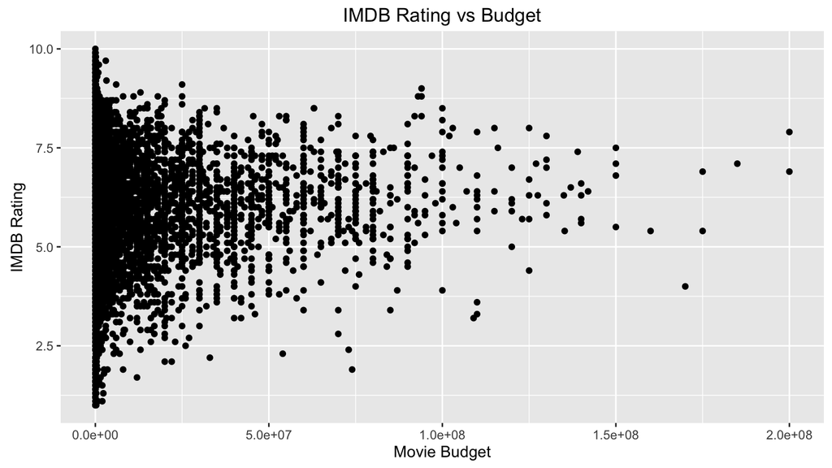

### Solution

Let’s look at a random sample of 5 of the movies:

| title | budget | rating |
| --- | --- | --- |
| Swamp Thing | 3000000 | 5.0 |
| Incident at Loch Ness | 1400000 | 6.4 |
| Princess and the Pirate, The | 2000000 | 6.7 |
| Prime Time, The | 150000 | 1.5 |
| Monty Python and the Holy Grail | 250000 | 8.4 |

**Both variables are numerical**. Here are the components of the Grammar of Graphics:

| `data` variable | `aes()`thetic attribute | `geom_`etric object |
| --- | --- | --- |
| `budget` | `x` | `point` |
| `rating` | `y` | `point` |

### Question

Does spending more on a movie yield higher IMDB ratings?

## Linegraph

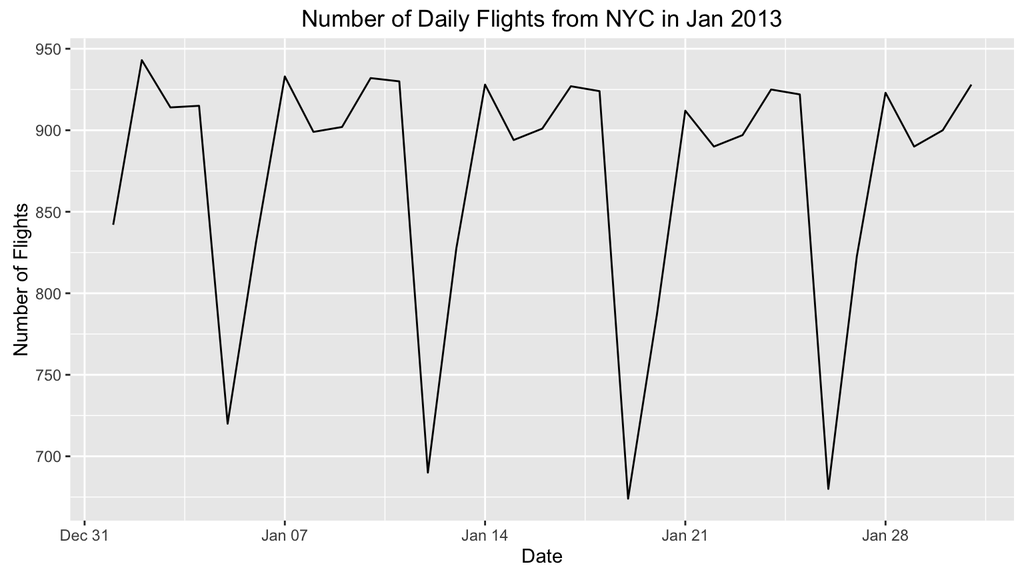

### Solution

Let’s look at a random sample of 5 of the dates:

| date | n |
| --- | --- |
| 2013-01-13 | 828 |
| 2013-01-07 | 933 |
| 2013-01-19 | 674 |
| 2013-01-25 | 922 |
| 2013-01-29 | 890 |

**Both variables are numerical (dates are technically numerical)**. Here are the components of the Grammar of Graphics:

| `data` variable | `aes()`thetic attribute | `geom_`etric object |
| --- | --- | --- |
| `date` | `x` | `line` |
| `n` | `y` | `line` |

**Note**: Why did we use `line` as the `geom_`etric object? Because lines suggest sequence/relationship, and points don’t.

### Question

Why are there drops in the number of flights?

## Boxplot

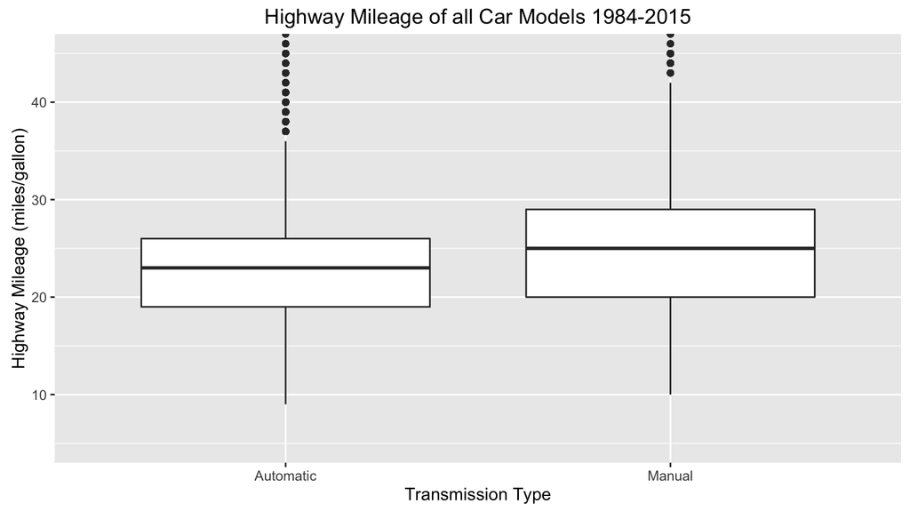

### Solution

Let’s look at a random sample of 5 of the car year/make/model matchings:

| name | trans | hwy |
| --- | --- | --- |
| 1996 Acura NSX | Manual | 22 |
| 2013 Buick LaCrosse eAssist | Automatic | 36 |
| 1996 Chevrolet C1500 Pickup 2WD | Manual | 18 |
| 2002 Volkswagen Jetta Wagon | Manual | 26 |
| 1984 Chevrolet G10/20 Sport Van 2WD | Automatic | 15 |

**`trans` type is categorical, whereas `hwy` is numerical**. Here are the components of the Grammar of Graphics:

| `data` variable | `aes()`thetic attribute | `geom_`etric object |
| --- | --- | --- |
| `trans` | `x` | `boxplot` |
| `hwy` | `y` | `boxplot` |

### Question

About what proportion of manual car models sold between 1984 and 2015 got 20 mpg or worse mileage?

## Bar Plot

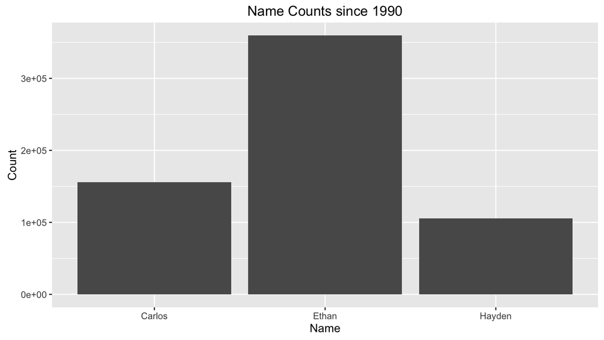

### Solution

Let’s look at all the data:

| name | n |
| --- | --- |
| Carlos | 155711 |
| Ethan | 359506 |
| Hayden | 105716 |

**Name is categorical**. Here are the components of the Grammar of Graphics:

| `data` variable | `aes()`thetic attribute | `geom_`etric object |
| --- | --- | --- |
| `name` | `x` | `bar` |
| `n` | `y` | `bar` |

### Question

About how many babies were named “Hayden” between 1990-2014?

## Histogram

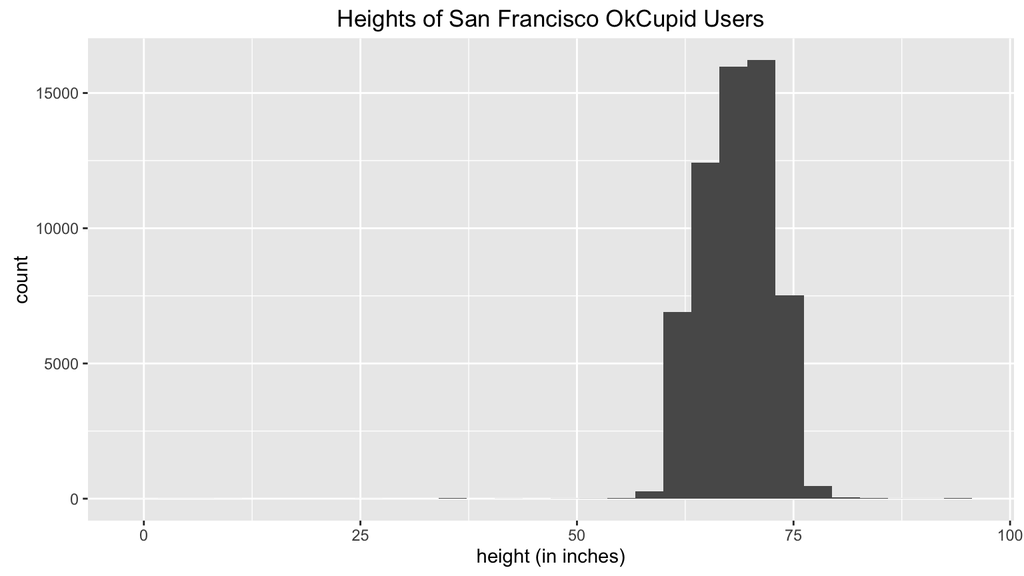

### Solution

Let’s look at a random sample of 5 of the users:

| sex | height |
| --- | --- |
| f | 65 |
| m | 75 |
| m | 65 |
| f | 64 |
| m | 69 |

**Height is numerical**. Here are the components of the Grammar of Graphics:

| `data` variable | `aes()`thetic attribute | `geom_`etric object |
| --- | --- | --- |
| `height` | `x` | `histogram` |

**Note**: We’ll see later there is no explicit `y` aesthetic here, because there is no explicit variable that maps to it, but rather it is computed internally.

### Question

What are the smallest and largest visible heights and what do you think of them? Also, think of one graph improvement to better convey information about SF OkCupid users.